# Assignment 4

## Submit as an HTML file

Print your Emory ID below

```python
print(2435513)
```

```
2435513
```

Import both the MatPlotLib and Numpy libraries

```python
import matplotlib.pyplot as plt
import numpy as np
```

1. For-loops to count conditional statements
- Define a custom list of people's ages  
  (write down ages for 8 people, between ten and fifty)
- Define an empty list called `list_eligible`
- Use a For-Loop that goes through the ages of the 8 people, then appends the  
  value `True` to `list_eligible` if their age is greater than or equal to 16  
  and `False` otherwise

```python
# Write your own code
list_ages = [13, 18, 22, 46, 39, 28, 31, 15]

list_eligible = []

for age in list_ages:
    if age > 16:
        list_eligible = list_eligible + [True]
    else:
        list_eligible = list_eligible + [False]

print(list_eligible)
```

```
[False, True, True, True, True, True, True, False]
```

1. This is a follow-up to question 1.
- If you run `np.sum(list_eligible)`, what value is Python assigning to  
  `True` or `False` elements in the sum? Write you answer as a comment.
- How would you use this information to count the amount of people who are  
  **NOT** eligible? Write code that answers this question.

```python
# Write your own code
np.sum(list_eligible)
# True values are counted as 1, while false values are counted as 0

# count ineligible entries
len(list_eligible) - np.sum(list_eligible)
```

```
2
```

1. Use a For-Loop for message automation
- Write your own list of customer names
- Print an automated message with the unique name of the customer that tells  
  them they've won a giveaway
- How many messages to do you expect to see? Write code that automatically  
  prints the size of the customer list

```python
# Write your own code
list_names = ["Alice", "Bob", "Christy", "Douglas", "Ellen", "Hank"]

for name in list_names:
    print("Congratulations " + name + "! You've won our giveaway!")

print(len(list_names))
```

```
Congratulations Alice! You've won our giveaway!
Congratulations Bob! You've won our giveaway!
Congratulations Christy! You've won our giveaway!
Congratulations Douglas! You've won our giveaway!
Congratulations Ellen! You've won our giveaway!
Congratulations Hank! You've won our giveaway!
6
```

1. For-Loops + Plotting
- Create an array of x-values with all the integers between 1 and 10
- Create a vector `vec_y1` where each element is computed from  
  the formula $ y_1 = 0.5x^4 + 2x^2 + 4x$.
- Create a vector `vec_y2` where each element is computed from  
  the formula $ y_2 = 2x^3 + 4x + 4$.
- Create an object `list_vectors` with elements `vec_y1` and `vec_y2`
- Create a for-loop that goes through each element of  
  `list_vectors` and plots each list of $y$ values against $x$

Note: The final output should be a 2 dimensional scatter plot with two sets,  
of points, with the $y_1$ and $y_2$ on the vertical axis, and the $x$ values  
on the horizontal axis. Remember to always label the axes to make it look  
more professional.

[output not shown]

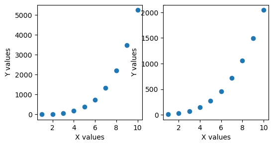

```python
# Write your own code

vec_x = np.array([1, 2, 3, 4, 5, 6, 7, 8, 9, 10])

vec_y1 = (0.5*vec_x**4)+(2*vec_x**2)+(4*vec_x)
vec_y2 = (2*vec_x**3)+(4*vec_x) + 4

list_vectors = [vec_y1, vec_y2]

fig, list_subfig = plt.subplots(1, 2, figsize = (6,3))
plt.tight_layout

index = 0
for y_values in list_vectors:
    list_subfig[index].scatter(x = vec_x, y = y_values)
    list_subfig[index].set_xlabel("X values")
    list_subfig[index].set_ylabel("Y values")
    index = index+1
```

1. Loops + Multiple Lists

Before starting, read the following information about nested loops:

https://www.w3schools.com/python/gloss_python_for_nested.asp

[figure not shown]

- Convert the following three lists to arrays

`list_lower = [93, 87, 83, 80, 75, 70, 65, 60, 55, 0]`  
`list_upper = [100,92, 86, 82, 79, 74, 69, 64, 59, 54]`  
`list_letters = ["A","A-","B+","B","B-","C+","C","C-","D","F"]`

- Convert the following list of student grades to an array

`list_studentgrades = [80, 70, 96, 65, 92]`

- Create a nested for-loop that outputs

"The student got a numeric grade of .... and their letter grade was ..."

Example of the procedure:

```python
# Write your own code
vec_lower = np.array([93, 87, 83, 80, 75, 70, 65, 60, 55, 0])
vec_upper = np.array([100, 92, 86, 82, 79, 74, 69, 64, 59, 54])
vec_letters = np.array(["A", "A-", "B+", "B", "B-", "C+", "C", "C-", "D", "F"])

vec_studentgrades = np.array([80, 70, 96, 65, 92])

for student_score in vec_studentgrades:
    index = 0
    for grade in vec_letters:
        if (student_score <= vec_upper[index]) & (student_score >= vec_lower[index]):
            print("The student got a numeric grade of " + str(student_score)+
                  " and a letter grade of " + str(vec_letters[index]) + ".")
            break
        else:
            index = index+1
```

```
The student got a numeric grade of 80 and a letter grade of B.
The student got a numeric grade of 70 and a letter grade of C+.
The student got a numeric grade of 96 and a letter grade of A.
The student got a numeric grade of 65 and a letter grade of C.
The student got a numeric grade of 92 and a letter grade of A-.
```